# Taller 3

Johan Ayala y Daniel Mayor

28/2/2022

## Cargue de las librerias

```r
library(ggplot2)
library(dplyr)
library(MASS)
library(readxl)
library(psych)
library(mfx)
```

## Carga de la base de datos y primeras visiones

Se debe tener encuenta lo siguiente:

- AP: Vale 0 si el niño está bajo el modelo de MF(Médico de Familia), y 1 si está bajo el modelo de MS(policlínicos y Médicos del Sector).
- Lactancia: Toma el valor 1 si el niño aún lacta al momento de la encuesta y 0 si el niño ya no lo hace.
- Edad: Edad(en días) del niño al momento de la pregunta.

```r
Datos <- read_excel("Lactancia.xlsx")
Prop_Lacta=Datos %>% group_by(Edad,AP) %>% summarise(N=n(),Lacta=sum(Lactancia==1))
Prop_Lacta$Propo=Prop_Lacta$Lacta/Prop_Lacta$N
```

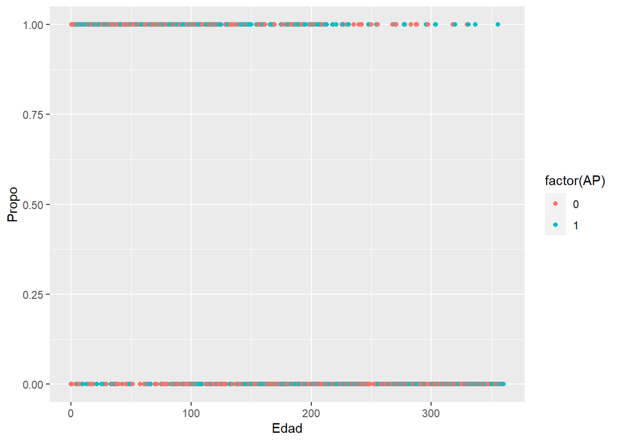

```r
qplot(Edad,Propo,col=factor(AP),data=Prop_Lacta)
```

• Haga un análisis descriptivo del conjunto de datos.

```r
describe(Datos)
```

```
##           vars    n   mean     sd median trimmed    mad  min    max  range skew
## Edad         1 1401 180.89 102.95 181.39  181.15 127.85 0.05 359.89 359.84 0.00
## AP           2 1401   0.41   0.49   0.00    0.39   0.00 0.00   1.00   1.00 0.35
## Lactancia    3 1401   0.33   0.47   0.00    0.29   0.00 0.00   1.00   1.00 0.71
##           kurtosis   se
## Edad         -1.14 2.75
## AP           -1.88 0.01
## Lactancia    -1.50 0.01
```

Como primera medida vemos como estan distribuidos los datos, donde nos encontramos que la edad promedio son 180 dias y ademas que tenemos un proporcion de 60 y 40 entre los niños que estan inscritos en programas, donde la mayoria provienen de MF, con una asimetria positiva, lo que nos dice es que los niños al inicio empiezan lactanto y al transcurrir de los dias lo van dejando.

```r
tab <- xtabs(formula = ~ Lactancia + AP, data = Datos)
tab.rel <- round( prop.table(x = tab, margin = 1), 3)

print( tab )
```

```
##          AP
## Lactancia   0   1
##         0 565 369
##         1 258 209
```

```r
print( tab.rel )
```

```
##          AP
## Lactancia     0     1
##         0 0.605 0.395
##         1 0.552 0.448
```

De las siguientes tablas podemos ver el detalle de cuantos niños estan lactando o no dependiendo del programa da salud al que este incrito la familia, esto lo vemos de forma general y en porcentajes. De lo cual vemos que son más los casos donde se lacta cuando pertenecen a MF que cuando pertenecen a MS, pero es mayor los que no estan lactando en el MF a comparacion de MS

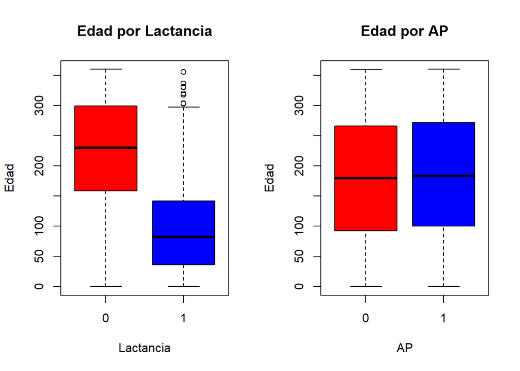

```r
par(mfrow = c(1, 2))
boxplot(Edad ~ Lactancia, data = Datos, col = c("red","blue"),
        main = "Edad por Lactancia", xlab = "Lactancia")
boxplot(Edad ~ AP, data = Datos, col = c("red","blue"),
        main = "Edad por AP", xlab = "AP")
```

Ya por ultimo vemos como estan distribuidas las variables, y como podemos ver en los box-plot, son mas los niños jovenes los que lactan que los mas viejos, sumado a que existen unos datos atipicos en esta distribucion, ademas podemos ver como se tiene una distribucion de edad bastante aceptable para los niños que pertenecen a los programas.

• Proponga un modelo estadístico para explicar la probabilidad de que un niño esté lactando en función de su edad (en días) y del modelo de atención primaria (MF/MS). Describa las componentes aleatoria y sistemática.

La variable aleatoria en este caso es la Lactancia, de donde se obtine 1 si el niño esta lactando o 0 donde no lo esta, como la variable es dicotomica se procedera entonces a realizar un modelo logit para esta clase de variables y las variables sistematicas en este caso son la AP que corresponde a si un bebe esta o no en el Programa MS(1) o MF(0) y la otra variable que vamos a usar es la Edad que se contempla como los dias de vida del bebe, donde podremos ver cual es el comportamiento que tienen los niños a lo largo de su primer año de vida(360 días).

```r
model1 <- glm(Lactancia ~ Edad+AP , data = Datos, family = "binomial")
```

#### Prueba de bondad de ajuste

```r
with(data = model1,
     expr = pchisq(q = null.deviance - deviance, df = df.null - df.residual,
                   lower.tail = F))
```

```
## [1] 1.187108e-118
```

Como vemos, en la prueba de significancia tuvimos un valor muy por debajo del 0.001 indica que el modelo en conjunto ajusta significativamente mejor que un modelo vacío (sin predictores), teniendo un buen modelo.

```r
summary(model1)
```

```
##
## Call:
## glm(formula = Lactancia ~ Edad + AP, family = "binomial", data = Datos)
##
## Deviance Residuals:
##     Min       1Q   Median       3Q      Max
## -2.0714  -0.6968  -0.3053   0.7013   2.7567
##
## Coefficients:
##               Estimate Std. Error z value Pr(>|z|)
## (Intercept)  1.7312206  0.1515018  11.427  < 2e-16 ***
## Edad        -0.0165600  0.0009136 -18.125  < 2e-16 ***
## AP           0.3777685  0.1433482   2.635  0.00841 **
## ---
## Signif. codes:  0 '***' 0.001 '**' 0.01 '*' 0.05 '.' 0.1 ' ' 1
##
## (Dispersion parameter for binomial family taken to be 1)
##
##     Null deviance: 1783.5  on 1400  degrees of freedom
## Residual deviance: 1240.4  on 1398  degrees of freedom
## AIC: 1246.4
##
## Number of Fisher Scoring iterations: 5
```

• Estime e INTERPRETE los parámetros del modelo propuesto.

### ODD-ratios

```r
round(x = exp( cbind( coef(model1), confint(model1) ) ), digits = 5)
```

```
##                       2.5 %  97.5 %
## (Intercept) 5.64754 4.21652 7.63964
## Edad        0.98358 0.98177 0.98529
## AP          1.45903 1.10233 1.93429
```

### Efectos Marginales

```r
logitmfx(formula = Lactancia ~ AP + Edad , data = Datos)
```

```
## Call:
## logitmfx(formula = Lactancia ~ AP + Edad, data = Datos)
##
## Marginal Effects:
##            dF/dx   Std. Err.        z     P>|z|
## AP    0.07158816  0.02750294   2.6029  0.009243 **
## Edad -0.00308956  0.00015455 -19.9906 < 2.2e-16 ***
## ---
## Signif. codes:  0 '***' 0.001 '**' 0.01 '*' 0.05 '.' 0.1 ' ' 1
##
## dF/dx is for discrete change for the following variables:
##
## [1] "AP"
```

• ¿La muestra proporciona evidencia estadísticamente significativa de que la probabilidad que un niño esté lactando depende de su edad? Justifique su respuesta.

Si, dado que en el modelo se tiene que el parametro de la variable Edad es significativa a un nivel del 0.05 segun el valor del P-value que se muestra arriba.

• ¿La muestra proporciona evidencia estadísticamente significativa de que la probabilidad que un niño esté lactando depende del modelo de atención primaria (MF/MS)? Justifique su respuesta.

Si, dado que en el modelo se tiene que el parametro de la variable de atención primaria (MF/MS) es significativa a un nivel del 0.05 segun el valor del P-value.

• ¿El efecto de la edad del niño sobre la probabilidad de que esté lactando depende del modelo de atención primaria? Justifique su respuesta.

• Estime la probabilidad de que un niño de 150 días de nacido y que está bajo el modelo de atención primaria MF esté lactando.

```r
D <- with(data = Datos,
          expr = data.frame(Edad = 150.000000, AP = 0,Lactancia=1))
D$prediction <- predict(model1, newdata = D, type = "response")
print( D )
```

```
##   Edad AP Lactancia prediction
## 1  150  0         1  0.3202165
```

• Haga un gráfico del modelo estimado junto con los datos. Comente.

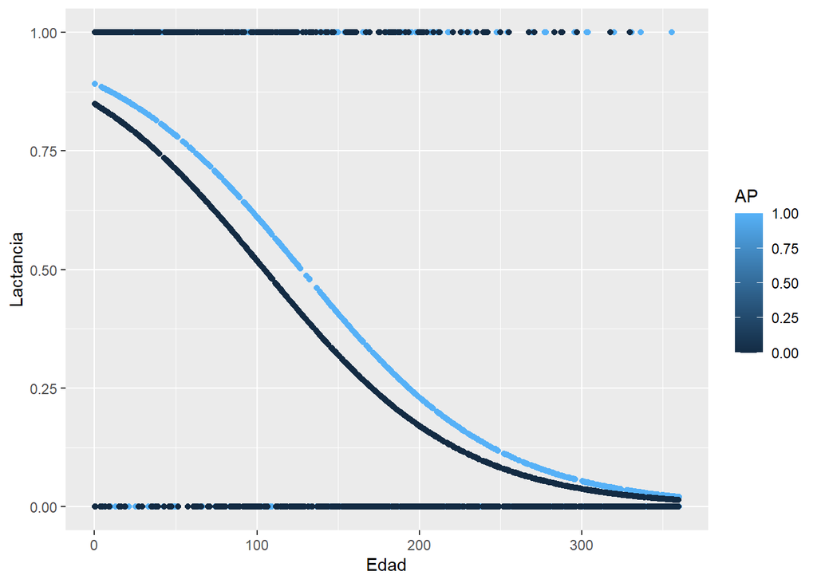

```r
Datos$prediction <- predict(model1, newdata = Datos, type = "response")

ggplot(Datos, aes(x = Edad, y = Lactancia, color=AP)) +
  geom_point()+
  geom_point(data = Datos, aes(y = Datos$prediction))
```

De la anterior gráfica podemos ver como al pertener al programa MF las probabilidades de lactar bajan con respecto a pertenercer al MS, por ende tenemos dos funciones completamente diferentes en el punto que inician pero que son de la misma forma. Vemos además, como se tiene una tendencia a la baja de las probabilidades, la función sigmoide nos dice que entre más joven sea el niño más probable es que este lactando.